# Replica App Grafico Dinamico

Sofía Palacios Cuevas

2023-10-20

# 1 Lectura de la base de datos y visualizaciones rápidas

## 1.1 Lectura de la base de datos

### 1.1.1 Librerías

```r
library(shiny)
library(tidyverse)
```

### 1.1.2 Curado de la base de datos

Leemos la base de datos

```r
datos_original <- read.csv("bd_lupus_shiny_developm.csv")
db_lupus<-datos_original[,c(6,26:51,52,53:62,63,85, 86, 130:155)]
# 6 -> sex
# 26:51 -> sledai_points (síntomas a partir de lupus), cada columna es un síntoma
# 52 -> sledai_date
# 53:62 -> acr_criterion del 1 al 10
# 63 -> acr_date
# 85 -> tiempo de diagnóstico
# 86 -> tiempo desde el primer síntoma
# 130:155 -> Nivel de satisfacción diferentes cuestiones vida diaria

db_lupus$sex___1<-as.factor(db_lupus$sex___1)
# 1 = mujer, 0 = hombre

# Cambiamos el nombre de las variables de los síntomas (sledai_points___2)
db_lupus <-rename(db_lupus, convulsion = sledai_points___1, psicosis = sledai_points___2, cerebro_organico = sledai_points___3,alteracion_visual = sledai_points___4,alteracion_nervios_craneales = sledai_points___5,cafalea_lupica = sledai_points___6,accidente_cerebrovascular = sledai_points___7,vasculitis = sledai_points___8,astritis = sledai_points___9,miositis = sledai_points___10,clindos_urinarios = sledai_points___11, hematuria = sledai_points___12,proteinuria = sledai_points___13,piuria = sledai_points___14,erupcion = sledai_points___15,alopecia = sledai_points___16,ulcera_mucosa = sledai_points___17,pleuresia = sledai_points___18,pericarditis = sledai_points___19,hipocomplemen = sledai_points___20,aumento_union = sledai_points___21,fiebre = sledai_points___22,trombocitopen = sledai_points___23,leucopenia = sledai_points___24,ninguno = sledai_points___25)
db_lupus <- na.omit(db_lupus)

# Cambiamos el nombre de las variables de los Colegio Americano de Reumatología (acr_criterion)
db_lupus <- rename(db_lupus, eritema_malar = acr_criterion___1, eritema_discoide = acr_criterion___2, fotosensibilidad = acr_criterion___3, ulceras_orales = acr_criterion___4, artritis_no_erosiva = acr_criterion___5, pleuresia_pericarditis = acr_criterion___6, desorden_renal = acr_criterion___7, desordenes_neurologicos = acr_criterion___8, trastornos_hematopoyetico = acr_criterion___9, desordenes_inmunologicos = acr_criterion___10)

# Cambiamos el nombre de las variables de nivel de satisfacción (brefn, n = 1, 2, ..., 26)
db_lupus <- rename(db_lupus, calidad_vida = bref1,salud = bref2, imped_por_dolor = bref3, cantidad_medicamento = bref4, disfruta_vida = bref5, vida_sin_sentido = bref6, concentracion = bref7, seguridad = bref8,ambiente_fisico_saludable = bref9,energia_suficiente = bref10,aceptar_apariencia = bref11,dinero_suficiente = bref12,info_disponible = bref13,oportunidad_ocio = bref14,capaz_desplazarse = bref15,sueno = bref16,actividades_diarias = bref17,capaz_trabajo = bref18,si_mismo = bref19,relaciones_personales = bref20,vida_sexual = bref21,apoyo_amigos = bref22,condiciones_vivienda = bref23,acceso_serv_sanitarios = bref24,transporte = bref25,frecuencia_sent_neg = bref26)

write.csv(db_lupus,file='C:/Users/sofia/OneDrive/Documentos/EI7/db_lupus.csv')
```

### 1.1.3 Resumen

```r
summary(db_lupus)
```

```
##  sex___1   convulsion        psicosis      cerebro_organico
##  0: 2    Min.   :0.0000   Min.   :0.0000   Min.   :0.0000
##  1:64    1st Qu.:0.0000   1st Qu.:0.0000   1st Qu.:0.0000
##          Median :0.0000   Median :0.0000   Median :0.0000
##          Mean   :0.0303   Mean   :0.1061   Mean   :0.2121
##          3rd Qu.:0.0000   3rd Qu.:0.0000   3rd Qu.:0.0000
##          Max.   :1.0000   Max.   :1.0000   Max.   :1.0000
##  sledai_points___conciencia alteracion_visual alteracion_nervios_craneales
##  Min.   :0.0000             Min.   :0.0000    Min.   :0.0000
##  1st Qu.:0.0000             1st Qu.:0.0000    1st Qu.:0.0000
##  Median :0.0000             Median :0.0000    Median :0.0000
##  Mean   :0.4394             Mean   :0.2727    Mean   :0.1818
##  3rd Qu.:1.0000             3rd Qu.:1.0000    3rd Qu.:0.0000
##  Max.   :1.0000             Max.   :1.0000    Max.   :1.0000
##  cafalea_lupica accidente_cerebrovascular   vasculitis        astritis
##  Min.   :0.0    Min.   :0.0000            Min.   :0.0000   Min.   :0.0000
##  1st Qu.:0.0    1st Qu.:0.0000            1st Qu.:0.0000   1st Qu.:0.0000
##  Median :0.5    Median :0.0000            Median :0.0000   Median :1.0000
##  Mean   :0.5    Mean   :0.0303            Mean   :0.3182   Mean   :0.6212
##  3rd Qu.:1.0    3rd Qu.:0.0000            3rd Qu.:1.0000   3rd Qu.:1.0000
##  Max.   :1.0    Max.   :1.0000            Max.   :1.0000   Max.   :1.0000
##     miositis      clindos_urinarios   hematuria      proteinuria
##  Min.   :0.0000   Min.   :0.00000   Min.   :0.000   Min.   :0.0000
##  1st Qu.:0.0000   1st Qu.:0.00000   1st Qu.:0.000   1st Qu.:0.0000
##  Median :0.0000   Median :0.00000   Median :0.000   Median :0.0000
##  Mean   :0.1818   Mean   :0.07576   Mean   :0.303   Mean   :0.3485
##  3rd Qu.:0.0000   3rd Qu.:0.00000   3rd Qu.:1.000   3rd Qu.:1.0000
##  Max.   :1.0000   Max.   :1.00000   Max.   :1.000   Max.   :1.0000
##      piuria          erupcion         alopecia      ulcera_mucosa
##  Min.   :0.0000   Min.   :0.0000   Min.   :0.0000   Min.   :0.0000
##  1st Qu.:0.0000   1st Qu.:0.0000   1st Qu.:0.0000   1st Qu.:0.0000
##  Median :0.0000   Median :0.0000   Median :1.0000   Median :0.0000
##  Mean   :0.0303   Mean   :0.3333   Mean   :0.5909   Mean   :0.3333
##  3rd Qu.:0.0000   3rd Qu.:1.0000   3rd Qu.:1.0000   3rd Qu.:1.0000
##  Max.   :1.0000   Max.   :1.0000   Max.   :1.0000   Max.   :1.0000
##    pleuresia        pericarditis    hipocomplemen    aumento_union
##  Min.   :0.00000   Min.   :0.0000   Min.   :0.0000   Min.   :0.0000
##  1st Qu.:0.00000   1st Qu.:0.0000   1st Qu.:0.0000   1st Qu.:0.0000
##  Median :0.00000   Median :0.0000   Median :0.0000   Median :0.0000
##  Mean   :0.06061   Mean   :0.1061   Mean   :0.2273   Mean   :0.1061
```

[output cut: 71 more lines]

```
##  Max.   :4.000   Max.   :5.000   Max.   :5.000         Max.   :5.000
##   apoyo_amigos   condiciones_vivienda acceso_serv_sanitarios   transporte
##  Min.   :1.000   Min.   :1.000        Min.   :1.00           Min.   :1.000
##  1st Qu.:2.000   1st Qu.:3.000        1st Qu.:3.00           1st Qu.:2.250
##  Median :3.000   Median :3.500        Median :3.50           Median :3.000
##  Mean   :3.152   Mean   :3.591        Mean   :3.47           Mean   :3.227
##  3rd Qu.:4.000   3rd Qu.:4.000        3rd Qu.:4.00           3rd Qu.:4.000
##  Max.   :5.000   Max.   :5.000        Max.   :5.00           Max.   :5.000
##  frecuencia_sent_neg
##  Min.   :1.000
##  1st Qu.:2.000
##  Median :2.000
##  Mean   :2.409
##  3rd Qu.:3.000
##  Max.   :4.000
```

### 1.1.4 Exploración de los datos

```r
db_lupus %>%
  filter(time_symptoms == 2)
```

| sex___1 | convulsion | psicosis | cerebro_organico | sledai_points___conciencia | alteracion_visual | alteracion_nervios_craneales | cafalea_lupica | accidente_cerebrovascular | vasculitis | astritis | miositis | clindos_urinarios | hematuria | proteinuria | piuria | erupcion | alopecia | ulcera_mucosa | pleuresia | pericarditis | hipocomplemen | aumento_union | fiebre | trombocitopen | leucopenia | ninguno | sledai_date | eritema_malar | eritema_discoide | … |
| --- | --- | --- | --- | --- | --- | --- | --- | --- | --- | --- | --- | --- | --- | --- | --- | --- | --- | --- | --- | --- | --- | --- | --- | --- | --- | --- | --- | --- | --- | --- |
| 1 | 0 | 0 | 0 | 0 | 1 | 0 | 0 | 0 | 0 | 1 | 0 | 0 | 1 | 1 | 0 | 0 | 0 | 1 | 0 | 1 | 0 | 0 | 1 | 0 | 0 | 0 | 04/05/2020 | 1 | 0 | … |
| 1 | 0 | 1 | 1 | 1 | 0 | 0 | 1 | 1 | 1 | 1 | 0 | 0 | 0 | 0 | 0 | 0 | 1 | 0 | 0 | 0 | 0 | 0 | 1 | 1 | 1 | 0 | 15/07/2021 | 0 | 0 | … |
| 1 | 0 | 0 | 0 | 1 | 0 | 0 | 0 | 0 | 1 | 1 | 0 | 0 | 0 | 0 | 0 | 1 | 1 | 0 | 0 | 0 | 1 | 0 | 0 | 0 | 0 | 0 | 25/01/2022 | 0 | 0 | … |
| 1 | 0 | 0 | 0 | 1 | 1 | 0 | 1 | 0 | 0 | 0 | 0 | 0 | 0 | 1 | 0 | 1 | 1 | 0 | 0 | 0 | 1 | 0 | 0 | 0 | 0 | 0 | 01/04/2022 | 1 | 1 | … |
| 1 | 0 | 0 | 0 | 1 | 0 | 1 | 1 | 0 | 0 | 0 | 0 | 0 | 0 | 1 | 0 | 0 | 0 | 0 | 0 | 0 | 0 | 0 | 0 | 0 | 0 | 0 | 02/08/2022 | 0 | 0 | … |
| 1 | 0 | 0 | 0 | 1 | 0 | 0 | 0 | 0 | 0 | 1 | 0 | 1 | 1 | 1 | 0 | 0 | 1 | 0 | 0 | 0 | 1 | 1 | 0 | 1 | 1 | 0 | 02/05/2023 | 0 | 0 | … |
| 1 | 0 | 0 | 0 | 1 | 1 | 0 | 0 | 0 | 0 | 1 | 1 | 0 | 1 | 0 | 0 | 0 | 1 | 1 | 0 | 0 | 0 | 0 | 0 | 0 | 1 | 0 | 20/05/2023 | 0 | 0 | … |

Ahora veamos, cuántas personas han sido diagnosticadas con lupus en los diferentes intervalos que establece la variable del *tiempo de diagnóstico*

```r
db_lupus %>%
  count(dx_time, wt = NULL, sort = T)
```

| dx_time | n |
| --- | --- |
| 1 | 13 |
| 2 | 6 |
| 4 | 4 |
| 5 | 4 |
| 3 | 3 |
| 6 | 3 |
| 7 | 3 |
| 9 | 3 |
| 10 | 3 |
| 12 | 3 |

[output cut: 14 more lines]

Ahora según los síntomas que han experimentado:

```r
db_lupus %>%
  count(time_symptoms, wt = NULL, sort = T)
```

| time_symptoms | n |
| --- | --- |
| 0 | 19 |
| 1 | 13 |
| 3 | 9 |
| 6 | 8 |
| 2 | 7 |
| 7 | 6 |
| 5 | 3 |
| 4 | 1 |

Ahora explorarmos las ocurrencias del tiempo *tiempo de diagnóstico* por *sexo*

```r
dxTime_sex<-db_lupus %>%
  count(dx_time, sex___1, wt = NULL)
```

Ahora de forma visual

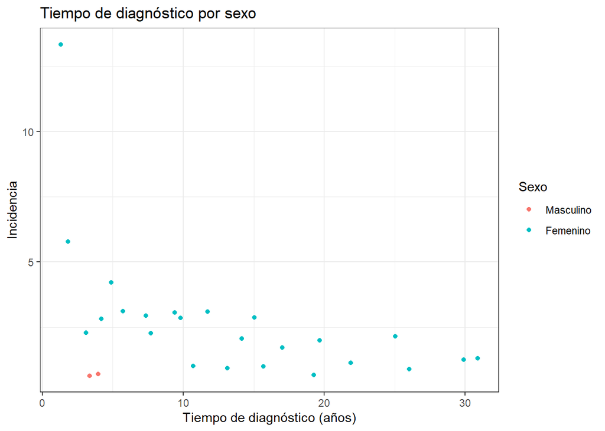

```r
dxTime_sex %>%
  ggplot(aes(dx_time, n, colour = sex___1))+
  geom_point(position = "jitter") +
  xlab("Tiempo de diagnóstico (años)") +
  ylab("Incidencia") +
  ggtitle("Tiempo de diagnóstico por sexo") +
  scale_colour_hue(labels = c("Masculino", "Femenino", "Otro")) +
  guides(colour=guide_legend(title = "Sexo")) +
  theme_bw()
```

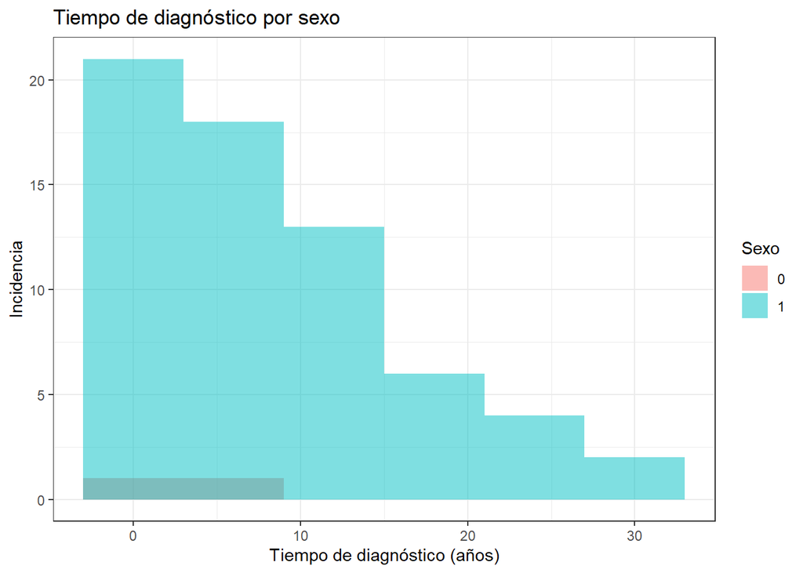

```r
db_lupus %>%
  ggplot(aes(dx_time, fill = sex___1))+
  geom_histogram(position = 'identity', alpha=0.5, binwidth = 6) +
  xlab("Tiempo de diagnóstico (años)") +
  ylab("Incidencia") +
  ggtitle("Tiempo de diagnóstico por sexo") +
  scale_colour_hue(labels = c("Masculino", "Femenino", "Otro")) +
  guides(fill=guide_legend(title = "Sexo")) +
  theme_bw()
```

Ahora explorarmos las ocurrencias del algún padecimiento experimentado a partir del diagnóstico (Miositis = inflamación muscular)

```r
miositis_sex<-db_lupus %>%
  count(miositis, sex___1, wt = NULL)
```

Ahora de forma visual (No tiene sentido)

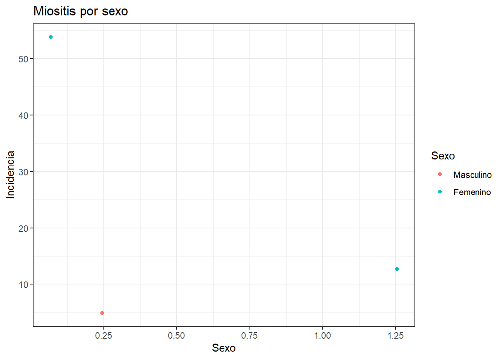

```r
miositis_sex %>%
  ggplot(aes(miositis, n, colour = sex___1))+
  geom_point(position = "jitter") +
  xlab("Sexo") +
  ylab("Incidencia") +
  ggtitle("Miositis por sexo") +
  scale_colour_hue(labels = c("Masculino", "Femenino", "Otro")) +
  guides(colour=guide_legend(title = "Sexo")) +
  theme_bw()
```

# 2 Gráficas

En esta sección se presentan los gráficos estáticos que queremos introducir a un ambiente reactivo, de modo que el usuario pueda escoger algún tema relacionado con la calidad de vida y vea cómo es la calidad de vida en pacientes con lupus, según el tiempo de daignótico que tienen. Podría ayudarles a entender qué esperar de la enfermedad en los próximos años.

## 2.1 Gráficas tiempo de diagnóstico - calidad de vida

Ahora explorarmos que tan satisfechos están con su vida, según el tiempo de diagnóstico

### 2.1.1 Calidad de vida

¿Cómo puntuaría su calidad de vida?

```r
dxTime_calidad_vida<-db_lupus %>%
  count(dx_time, calidad_vida, wt = NULL)

dxTime_calidad_vida$calidad_vida<-as.factor(dxTime_calidad_vida$calidad_vida)
```

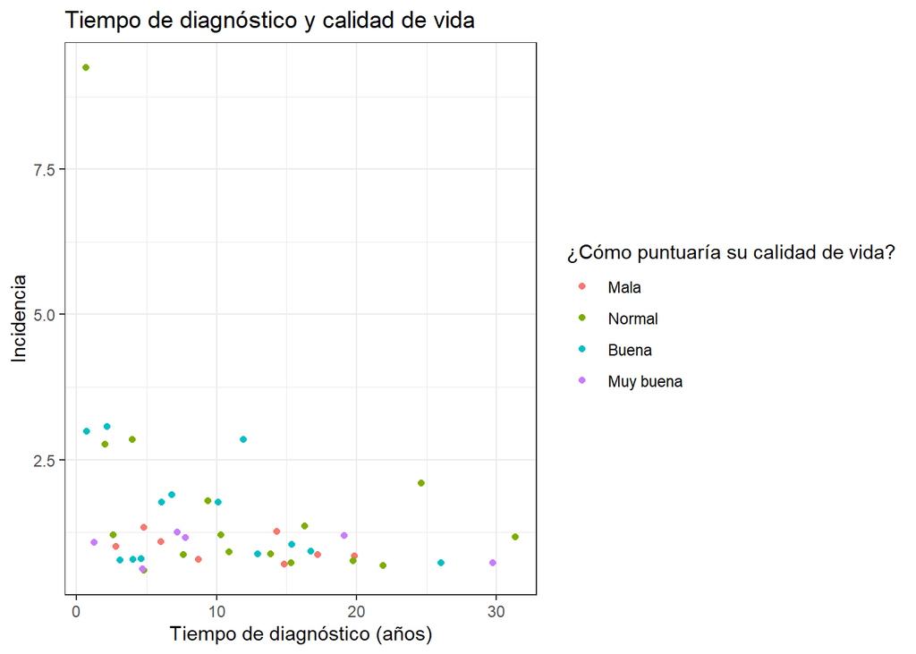

```r
dxTime_calidad_vida %>%
  ggplot(aes(dx_time, n, colour = calidad_vida))+
  geom_point(position = "jitter") +
  xlab("Tiempo de diagnóstico (años)") +
  ylab("Incidencia") +
  ggtitle("Tiempo de diagnóstico y calidad de vida") +
  scale_colour_hue(labels = c("Mala", "Normal", "Buena", "Muy buena")) + #Checar base de datos (0 personas con "muy mala"?)
  guides(colour=guide_legend(title = "¿Cómo puntuaría su calidad de vida?")) +
  theme_bw()
```

Esta gráfica indica el nivel de satisfacción de los pacientes respecto a su calidad de vida, según el tiempo de diagnóstico.

### 2.1.2 Salud

¿Cuán satisfecho está con su salud?

```r
dxTime_salud<-db_lupus %>%
  count(dx_time, salud, wt = NULL)

dxTime_salud$salud<-as.factor(dxTime_salud$salud)
```

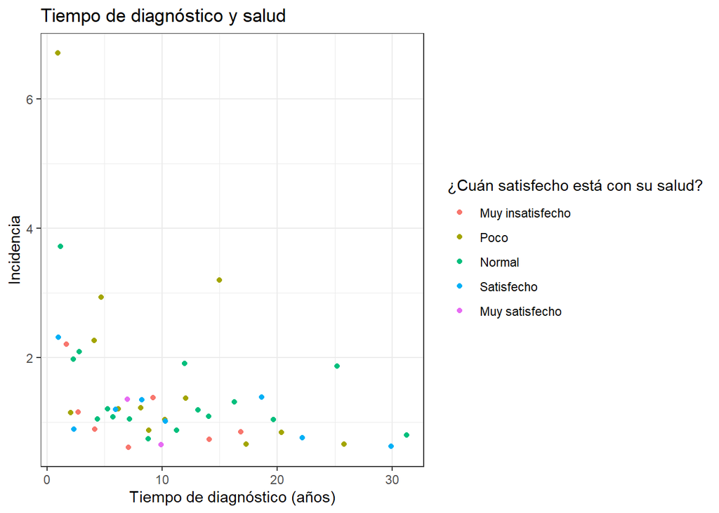

```r
dxTime_salud %>%
  ggplot(aes(dx_time, n, colour = salud))+
  geom_point(position = "jitter") +
  xlab("Tiempo de diagnóstico (años)") +
  ylab("Incidencia") +
  ggtitle("Tiempo de diagnóstico y salud") +
  scale_colour_hue(labels = c("Muy insatisfecho", "Poco", "Normal", "Satisfecho", "Muy satisfecho")) +
  guides(colour=guide_legend(title = "¿Cuán satisfecho está con su salud?")) +
  theme_bw()
```

Esta gráfica indica el nivel de satisfacción de los pacientes respecto a su salud, según el tiempo de diagnóstico.

### 2.1.3 Impedimento por dolor

¿Hasta qué punto piensa que el dolor (físico) le impide hacer lo que necesita? - En las últimas semas

```r
dxTime_imped_por_dolor<-db_lupus %>%
  count(dx_time, imped_por_dolor, wt = NULL)

dxTime_imped_por_dolor$imped_por_dolor<-as.factor(dxTime_imped_por_dolor$imped_por_dolor)
```

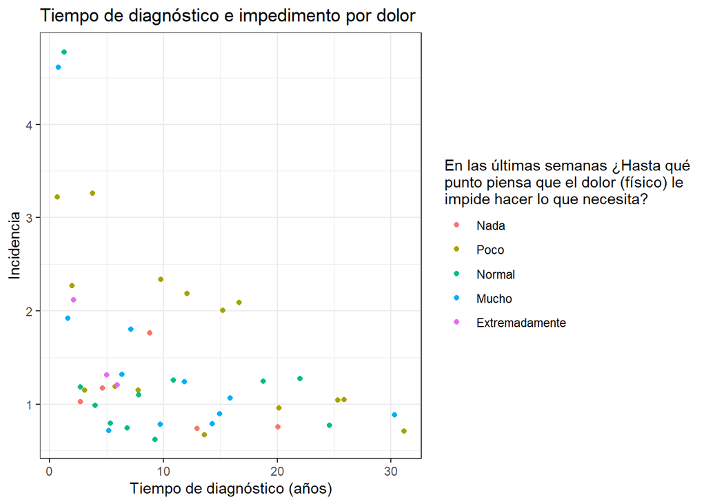

```r
dxTime_imped_por_dolor %>%
  ggplot(aes(dx_time, n, colour = imped_por_dolor))+
  geom_point(position = "jitter") +
  xlab("Tiempo de diagnóstico (años)") +
  ylab("Incidencia") +
  ggtitle("Tiempo de diagnóstico e impedimento por dolor") +
  scale_colour_hue(labels = c("Nada", "Poco", "Normal", "Mucho", "Extremadamente")) +
  guides(colour=guide_legend(title = "En las últimas semanas ¿Hasta qué
punto piensa que el dolor (físico) le
impide hacer lo que necesita?")) +
  theme_bw()
```

Esta gráfica indica la incidencia del nivel de impedimento que el dolor causa en los pacientes, con determinado tiempo de diagnóstico, para realizar sus actividades diarias.

### 2.1.4 Cantidad de medicamento

En las últimas semanas ¿Cuánto necesita de cualquier tratamiento médico para funcionar en su vida diaria?

```r
dxTime_cantidad_medicamento<-db_lupus %>%
  count(dx_time, cantidad_medicamento, wt = NULL)

dxTime_cantidad_medicamento$cantidad_medicamento<-as.factor(dxTime_cantidad_medicamento$cantidad_medicamento)
```

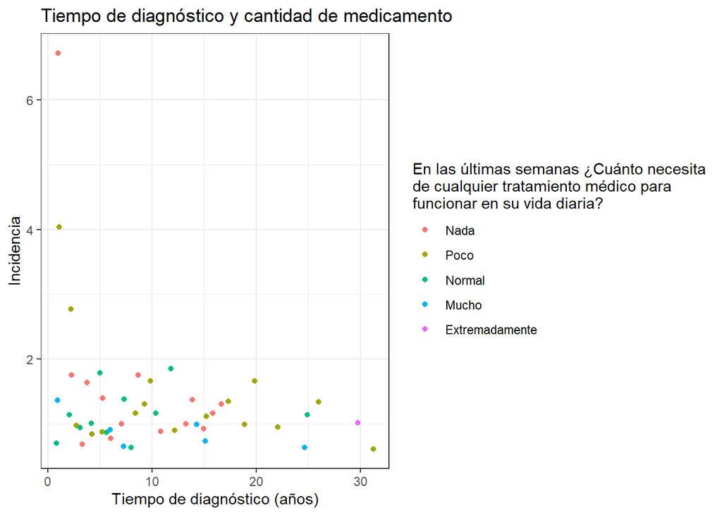

```r
dxTime_cantidad_medicamento %>%
  ggplot(aes(dx_time, n, colour = cantidad_medicamento))+
  geom_point(position = "jitter") +
  xlab("Tiempo de diagnóstico (años)") +
  ylab("Incidencia") +
  ggtitle("Tiempo de diagnóstico y cantidad de medicamento") +
  scale_colour_hue(labels = c("Nada", "Poco", "Normal", "Mucho", "Extremadamente")) +
  guides(colour=guide_legend(title = "En las últimas semanas ¿Cuánto necesita
de cualquier tratamiento médico para
funcionar en su vida diaria?")) +
  theme_bw()
```

Esta gráfica indica cuánto medicamento debe utilizar un paciente para realizar sus actividades diarias, según el tiempo de diagnóstico.

### 2.1.5 ¿Disfruta su vida?

¿Cuánto disfruta de la vida?

```r
dxTime_disfruta_vida<-db_lupus %>%
  count(dx_time, disfruta_vida, wt = NULL)

dxTime_disfruta_vida$disfruta_vida<-as.factor(dxTime_disfruta_vida$disfruta_vida)
```

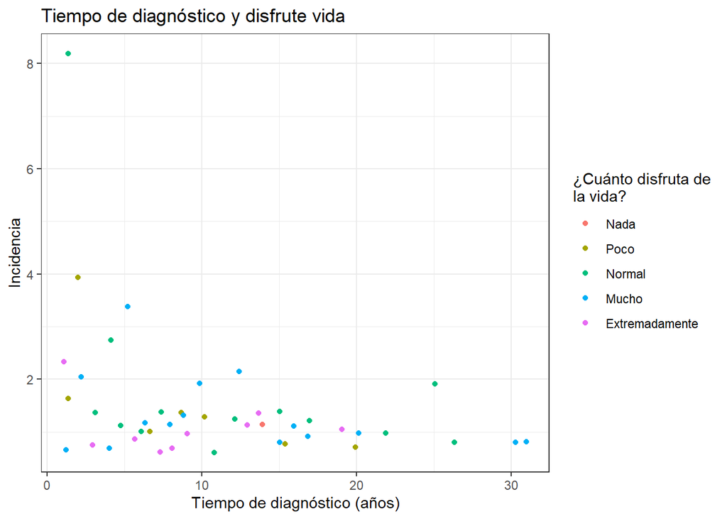

```r
dxTime_disfruta_vida %>%
  ggplot(aes(dx_time, n, colour = disfruta_vida))+
  geom_point(position = "jitter") +
  xlab("Tiempo de diagnóstico (años)") +
  ylab("Incidencia") +
  ggtitle("Tiempo de diagnóstico y disfrute vida") +
  scale_colour_hue(labels = c("Nada", "Poco", "Normal", "Mucho", "Extremadamente")) +
  guides(colour=guide_legend(title = "¿Cuánto disfruta de
la vida?")) +
  theme_bw()
```

Esta gráfica indica el nivel de satisfacción de los pacientes respecto a su vida, según el tiempo de diagnóstico.

### 2.1.6 Sentido de la vida

¿Hasta que punto siente que su vida tiene sentido?

```r
dxTime_vida_sin_sentido<-db_lupus %>%
  count(dx_time, vida_sin_sentido, wt = NULL)

dxTime_vida_sin_sentido$vida_sin_sentido<-as.factor(dxTime_vida_sin_sentido$vida_sin_sentido)
```

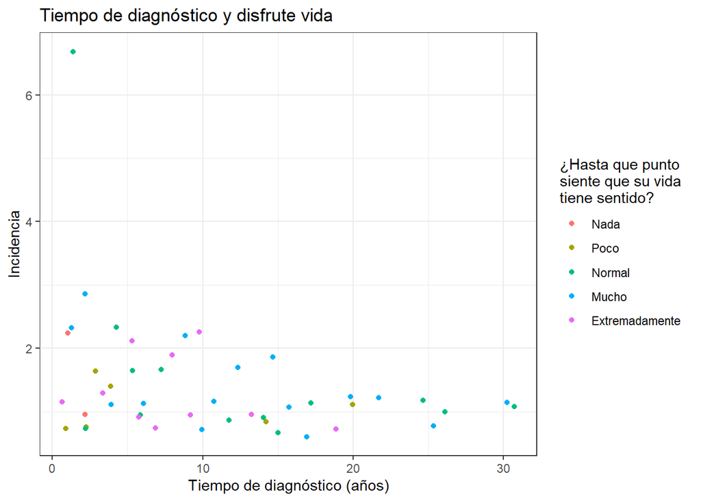

```r
dxTime_vida_sin_sentido %>%
  ggplot(aes(dx_time, n, colour = vida_sin_sentido))+
  geom_point(position = "jitter") +
  xlab("Tiempo de diagnóstico (años)") +
  ylab("Incidencia") +
  ggtitle("Tiempo de diagnóstico y disfrute vida") +
  scale_colour_hue(labels = c("Nada", "Poco", "Normal", "Mucho", "Extremadamente")) +
  guides(colour=guide_legend(title = "¿Hasta que punto
siente que su vida
tiene sentido?")) +
  theme_bw()
```

Esta gráfica indica hasta qué punto los pacientes sienten que su vida tiene sentido, según el tiempo de diagnóstico.

### 2.1.7 Concentración

¿Cuál es su capacidad de concentración?

```r
dxTime_concentracion<-db_lupus %>%
  count(dx_time, concentracion, wt = NULL)

dxTime_concentracion$concentracion<-as.factor(dxTime_concentracion$concentracion)
```

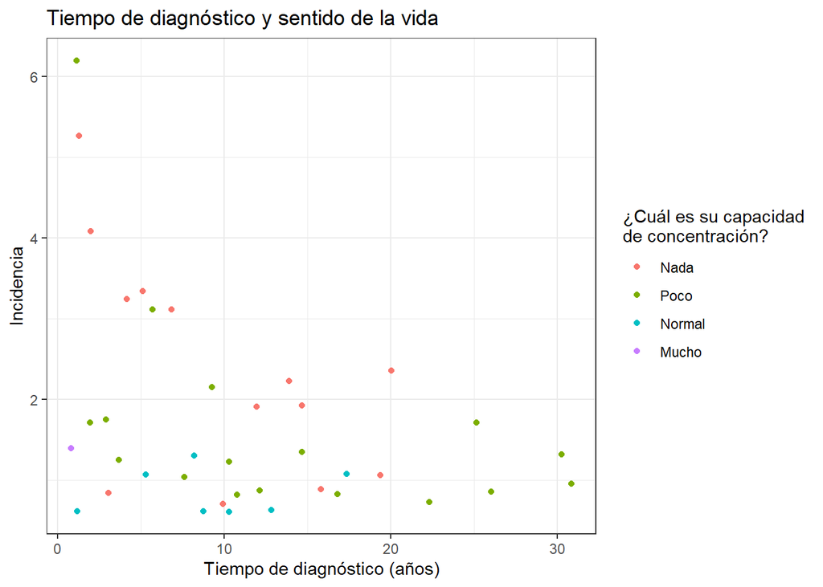

```r
dxTime_concentracion %>%
  ggplot(aes(dx_time, n, colour = concentracion))+
  geom_point(position = "jitter") +
  xlab("Tiempo de diagnóstico (años)") +
  ylab("Incidencia") +
  ggtitle("Tiempo de diagnóstico y sentido de la vida") +
  scale_colour_hue(labels = c("Nada","Poco", "Normal", "Mucho", "Extremadamente")) + # empieza en 2
  guides(colour=guide_legend(title = "¿Cuál es su capacidad
de concentración?")) +
  theme_bw()
```

Esta gráfica indica a qué nivel se pueden concentrar los pacientes, según el tiempo de diagnóstico.

### 2.1.8 Seguridad

¿Cuánta seguridad siente en su vida diaria?

```r
dxTime_seguridad<-db_lupus %>%
  count(dx_time, seguridad, wt = NULL)

dxTime_seguridad$seguridad<-as.factor(dxTime_seguridad$seguridad)
```

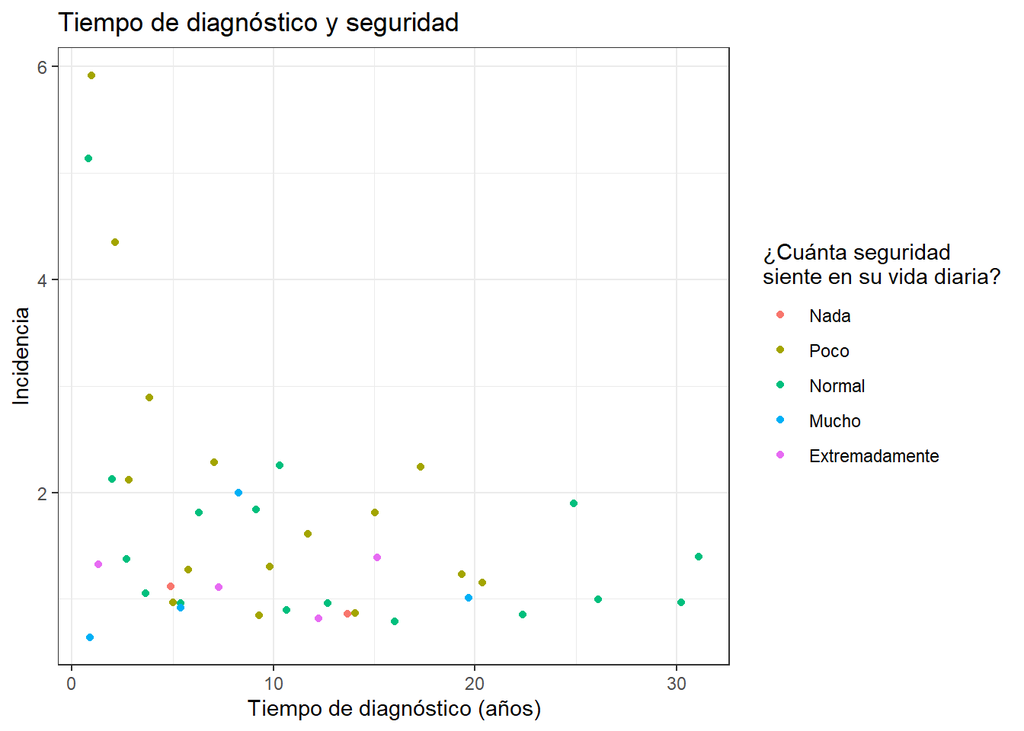

```r
dxTime_seguridad %>%
  ggplot(aes(dx_time, n, colour = seguridad))+
  geom_point(position = "jitter") +
  xlab("Tiempo de diagnóstico (años)") +
  ylab("Incidencia") +
  ggtitle("Tiempo de diagnóstico y seguridad") +
  scale_colour_hue(labels = c("Nada", "Poco", "Normal", "Mucho", "Extremadamente")) +
  guides(colour=guide_legend(title = "¿Cuánta seguridad
siente en su vida diaria?")) +
  theme_bw()
```

Esta gráfica indica qué tan seguros se sienten los pacientes en su día a día, según el tiempo de diagnóstico.

### 2.1.9 Ambiente físico saludable

¿Cuán saludable es el ambiente físico a su alrededor?

```r
dxTime_ambiente_fisico_saludable<-db_lupus %>%
  count(dx_time, ambiente_fisico_saludable, wt = NULL)

dxTime_ambiente_fisico_saludable$ambiente_fisico_saludable<-as.factor(dxTime_ambiente_fisico_saludable$ambiente_fisico_saludable)
```

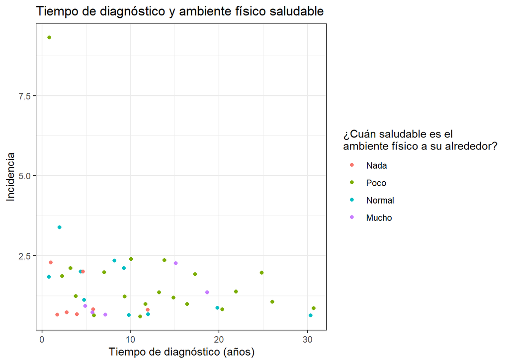

```r
dxTime_ambiente_fisico_saludable %>%
  ggplot(aes(dx_time, n, colour = ambiente_fisico_saludable))+
  geom_point(position = "jitter") +
  xlab("Tiempo de diagnóstico (años)") +
  ylab("Incidencia") +
  ggtitle("Tiempo de diagnóstico y ambiente físico saludable") +
  scale_colour_hue(labels = c("Nada", "Poco", "Normal", "Mucho", "Extremadamente")) + # Empieza en 2
  guides(colour=guide_legend(title = "¿Cuán saludable es el
ambiente físico a su alrededor?")) +
  theme_bw()
```

Esta gráfica indica cuántos pacientes consideran que tienen un ambiente físico nada, poco, normal, muy o extremadamente saludable a su alrededor.

### 2.1.10 Capacidad para desplazarse

¿Es capaz de desplazarse de un lugar a otro?

```r
dxTime_capaz_desplazarse<-db_lupus %>%
  count(dx_time, capaz_desplazarse, wt = NULL)

dxTime_capaz_desplazarse$capaz_desplazarse<-as.factor(dxTime_capaz_desplazarse$capaz_desplazarse)
```

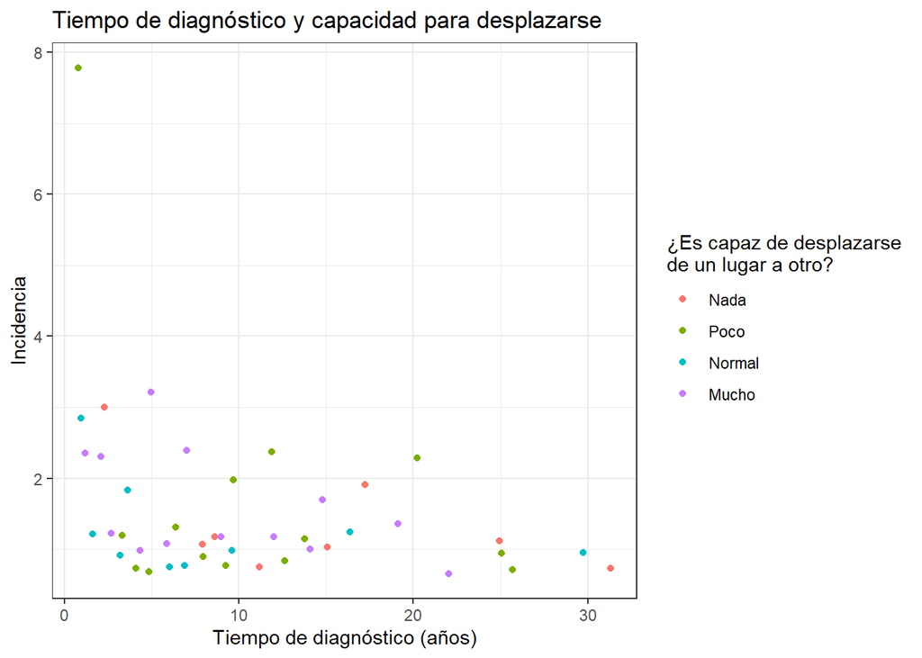

```r
dxTime_capaz_desplazarse %>%
  ggplot(aes(dx_time, n, colour = capaz_desplazarse))+
  geom_point(position = "jitter") +
  xlab("Tiempo de diagnóstico (años)") +
  ylab("Incidencia") +
  ggtitle("Tiempo de diagnóstico y capacidad para desplazarse") +
  scale_colour_hue(labels = c("Nada", "Poco", "Normal", "Mucho", "Extremadamente")) + # Empieza en 2
  guides(colour=guide_legend(title = "¿Es capaz de desplazarse
de un lugar a otro?")) +
  theme_bw()
```

Esta gráfica indica cuántos pacientes se consideran nada, poco, normal, muy o extremadamente capaces de desplazarse, según el tiempo de diagnóstico.

### 2.1.11 Suficiente energía

¿Tiene energía suficiente para su vida diaria?

```r
dxTime_energia_suficiente<-db_lupus %>%
  count(dx_time, energia_suficiente, wt = NULL)

dxTime_energia_suficiente$energia_suficiente<-as.factor(dxTime_energia_suficiente$energia_suficiente)
```

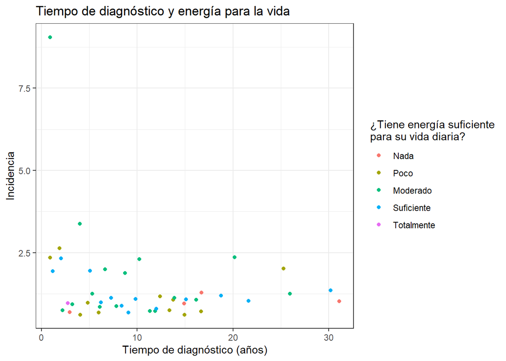

```r
dxTime_energia_suficiente %>%
  ggplot(aes(dx_time, n, colour = energia_suficiente))+
  geom_point(position = "jitter") +
  xlab("Tiempo de diagnóstico (años)") +
  ylab("Incidencia") +
  ggtitle("Tiempo de diagnóstico y energía para la vida") +
  scale_colour_hue(labels = c("Nada", "Poco", "Moderado", "Suficiente", "Totalmente")) +
  guides(colour=guide_legend(title = "¿Tiene energía suficiente
para su vida diaria?")) +
  theme_bw()
```

Esta gráfica indica cuántos pacientes consideran que tienen nada, poco, moderado, suficiente o total energía para su vida diaria, según el tiempo de diagnóstico.

### 2.1.12 Aceptación de la apariencia

¿Es capaz de aceptar su apariencia física?

```r
dxTime_aceptar_apariencia<-db_lupus %>%
  count(dx_time, aceptar_apariencia, wt = NULL)

dxTime_aceptar_apariencia$aceptar_apariencia<-as.factor(dxTime_aceptar_apariencia$aceptar_apariencia)
```

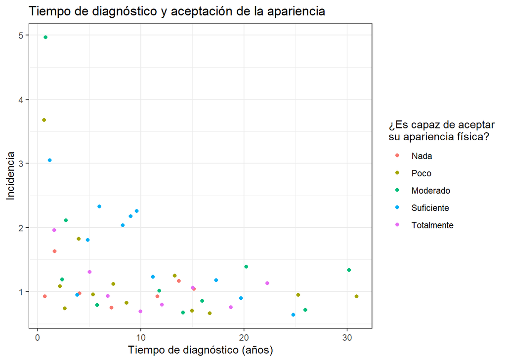

```r
dxTime_aceptar_apariencia %>%
  ggplot(aes(dx_time, n, colour = aceptar_apariencia))+
  geom_point(position = "jitter") +
  xlab("Tiempo de diagnóstico (años)") +
  ylab("Incidencia") +
  ggtitle("Tiempo de diagnóstico y aceptación de la apariencia") +
  scale_colour_hue(labels = c("Nada", "Poco", "Moderado", "Suficiente", "Totalmente")) +
  guides(colour=guide_legend(title = "¿Es capaz de aceptar
su apariencia física?")) +
  theme_bw()
```

Esta gráfica indica cuántos pacientes se consideran nada, poco, moderado, suficiente o totalmente capaces de aceptar su apariencia física, según el tiempo de diagnóstico.

### 2.1.13 Suficiente dinero

¿Tiene suficiente dinero para cubrir sus necesidades?

```r
dxTime_dinero_suficiente<-db_lupus %>%
  count(dx_time, dinero_suficiente, wt = NULL)

dxTime_dinero_suficiente$dinero_suficiente<-as.factor(dxTime_dinero_suficiente$dinero_suficiente)
```

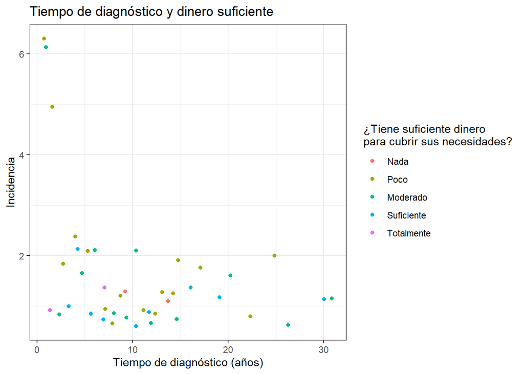

```r
dxTime_dinero_suficiente %>%
  ggplot(aes(dx_time, n, colour = dinero_suficiente))+
  geom_point(position = "jitter") +
  xlab("Tiempo de diagnóstico (años)") +
  ylab("Incidencia") +
  ggtitle("Tiempo de diagnóstico y dinero suficiente") +
  scale_colour_hue(labels = c("Nada", "Poco", "Moderado", "Suficiente", "Totalmente")) +
  guides(colour=guide_legend(title = "¿Tiene suficiente dinero
para cubrir sus necesidades?")) +
  theme_bw()
```

Esta gráfica indica cuántos pacientes tienen nada, poco, moderado, suficiente o total solvencia económica para cubrir sus necesidades, según el tiempo de diagnóstico.

### 2.1.14 Información disponible

¿Qué disponible tiene la información que necesita en su vida diaria?

```r
dxTime_info_disponible<-db_lupus %>%
  count(dx_time, info_disponible, wt = NULL)

dxTime_info_disponible$info_disponible<-as.factor(dxTime_info_disponible$info_disponible)
```

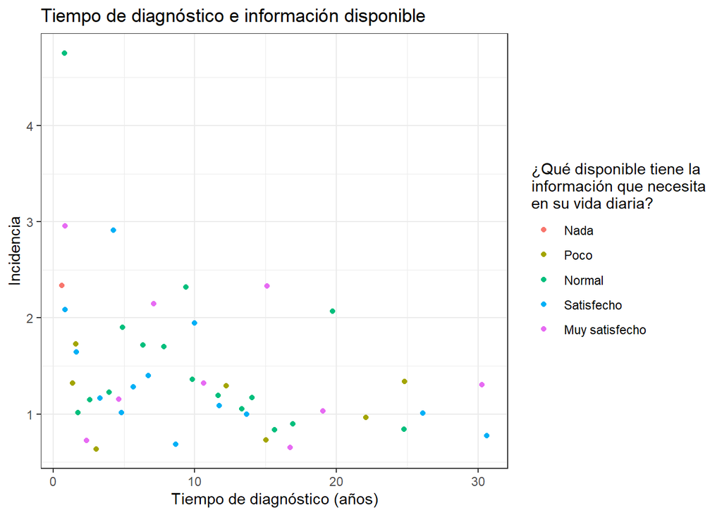

```r
dxTime_info_disponible %>%
  ggplot(aes(dx_time, n, colour = info_disponible))+
  geom_point(position = "jitter") +
  xlab("Tiempo de diagnóstico (años)") +
  ylab("Incidencia") +
  ggtitle("Tiempo de diagnóstico e información disponible") +
  scale_colour_hue(labels = c("Nada", "Poco", "Normal", "Satisfecho", "Muy satisfecho")) +
  guides(colour=guide_legend(title = "¿Qué disponible tiene la
información que necesita
en su vida diaria?")) +
  theme_bw()
```

Esta gráfica indica el grado de información disponible necesaria en la vida diaria del sujeto, relacionada con el tiempo de diagnóstico.

### 2.1.15 Oportunidad de ocio

¿Hasta qué punto tiene oportunidad para realizar actividades de ocio?

```r
dxTime_oportunidad_ocio<-db_lupus %>%
  count(dx_time, oportunidad_ocio, wt = NULL)

dxTime_oportunidad_ocio$oportunidad_ocio<-as.factor(dxTime_oportunidad_ocio$oportunidad_ocio)
```

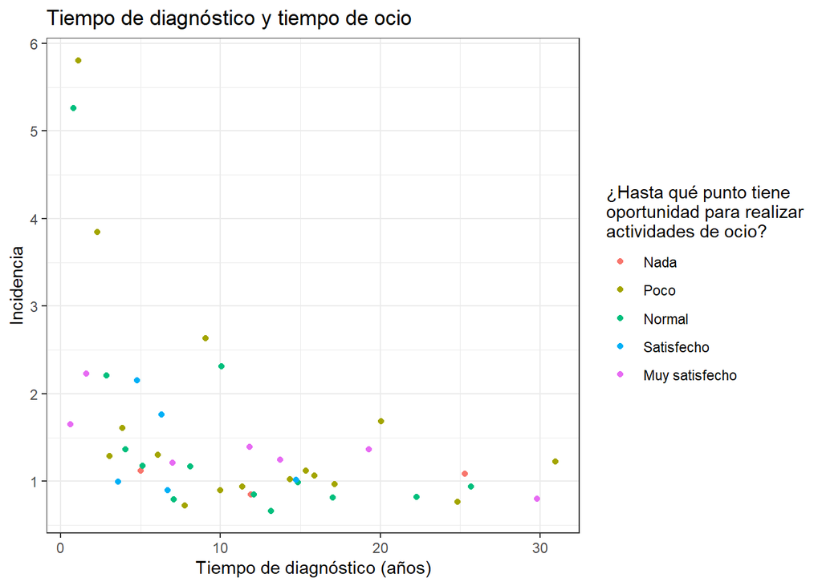

```r
dxTime_oportunidad_ocio %>%
  ggplot(aes(dx_time, n, colour = oportunidad_ocio))+
  geom_point(position = "jitter") +
  xlab("Tiempo de diagnóstico (años)") +
  ylab("Incidencia") +
  ggtitle("Tiempo de diagnóstico y tiempo de ocio") +
  scale_colour_hue(labels = c("Nada", "Poco", "Normal", "Satisfecho", "Muy satisfecho")) +
  guides(colour=guide_legend(title = "¿Hasta qué punto tiene
oportunidad para realizar
actividades de ocio?")) +
  theme_bw()
```

Esta gráfica indica el grado de oportunidad que tiene una persona para poder realizar actividades de ocio, relacionado con el tiempo de diagnóstico.

### 2.1.16 Sueño

¿Cuán satisfecho está con su sueño?

```r
dxTime_sueno<-db_lupus %>%
  count(dx_time, sueno, wt = NULL)

dxTime_sueno$sueno<-as.factor(dxTime_sueno$sueno)
```

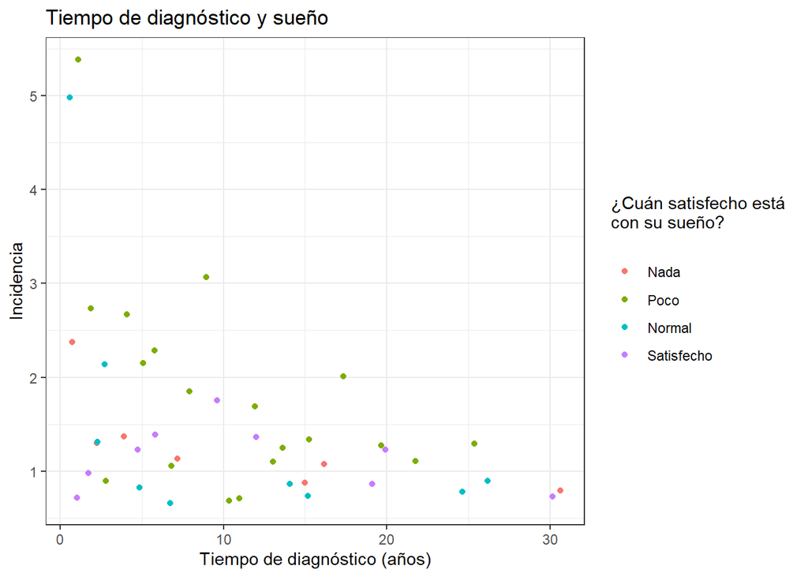

```r
dxTime_sueno %>%
  ggplot(aes(dx_time, n, colour = sueno))+
  geom_point(position = "jitter") +
  xlab("Tiempo de diagnóstico (años)") +
  ylab("Incidencia") +
  ggtitle("Tiempo de diagnóstico y sueño") +
  scale_colour_hue(labels = c("Nada", "Poco", "Normal", "Satisfecho", "Muy satisfecho")) +
  guides(colour=guide_legend(title = "¿Cuán satisfecho está
con su sueño?
")) +
  theme_bw()
```

Esta gráfica indica el nivel de satisfacción de una persona con respecto a su sueño, mismo que se responde tomando en cuenta la calidad, horas de sueño, entre otros factores, relacionado con el tiempo de diagnóstico.

### 2.1.17 Actividades diarias

¿Cuán satisfecho está con su habilidad para realizar sus actividades de la vida diaria?

```r
dxTime_actividades_diarias<-db_lupus %>%
  count(dx_time, actividades_diarias, wt = NULL)

dxTime_actividades_diarias$actividades_diarias<-as.factor(dxTime_actividades_diarias$actividades_diarias)
```

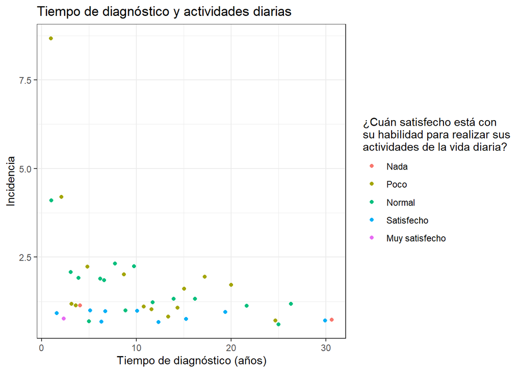

```r
dxTime_actividades_diarias %>%
  ggplot(aes(dx_time, n, colour = actividades_diarias))+
  geom_point(position = "jitter") +
  xlab("Tiempo de diagnóstico (años)") +
  ylab("Incidencia") +
  ggtitle("Tiempo de diagnóstico y actividades diarias") +
  scale_colour_hue(labels = c("Nada", "Poco", "Normal", "Satisfecho", "Muy satisfecho")) +
  guides(colour=guide_legend(title = "¿Cuán satisfecho está con
su habilidad para realizar sus
actividades de la vida diaria?")) +
  theme_bw()
```

Esta gráfica indica el nivel de satisfacción de una persona con su habilidad para realizar sus actividades de la vida diaria, relacionado con el tiempo de diagnóstico.

### 2.1.18 Capacidad de trabajo

¿Cuán satisfecho está con su capacidad de trabajo?

```r
dxTime_capaz_trabajo<-db_lupus %>%
  count(dx_time, capaz_trabajo, wt = NULL)

dxTime_capaz_trabajo$capaz_trabajo<-as.factor(dxTime_capaz_trabajo$capaz_trabajo)
```

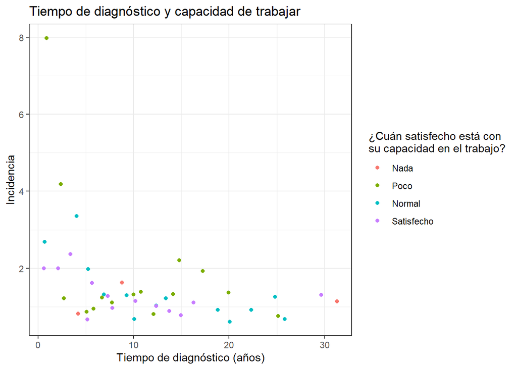

```r
dxTime_capaz_trabajo %>%
  ggplot(aes(dx_time, n, colour = capaz_trabajo))+
  geom_point(position = "jitter") +
  xlab("Tiempo de diagnóstico (años)") +
  ylab("Incidencia") +
  ggtitle("Tiempo de diagnóstico y capacidad de trabajar") +
  scale_colour_hue(labels = c("Nada", "Poco", "Normal", "Satisfecho", "Muy satisfecho")) +
  guides(colour=guide_legend(title = "¿Cuán satisfecho está con
su capacidad en el trabajo?")) +
  theme_bw()
```

Esta gráfica indica el grado de satisfacción de la persona, relacionado a su capacidad de trabajo, relacionado con el tiempo de diagnóstico.

### 2.1.19 Satisfacción de si mismo

¿Cuán satisfecho está de sí mismo?

```r
dxTime_si_mismo<-db_lupus %>%
  count(dx_time, si_mismo, wt = NULL)

dxTime_si_mismo$si_mismo<-as.factor(dxTime_si_mismo$si_mismo)
```

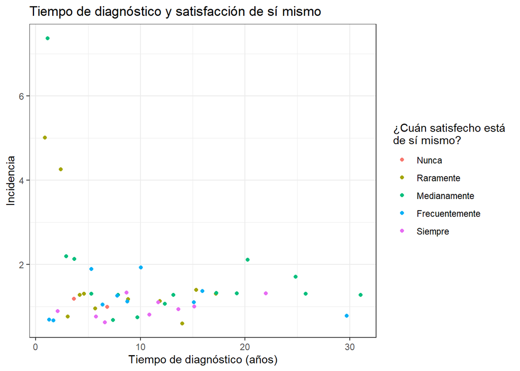

```r
dxTime_si_mismo %>%
  ggplot(aes(dx_time, n, colour = si_mismo))+
  geom_point(position = "jitter") +
  xlab("Tiempo de diagnóstico (años)") +
  ylab("Incidencia") +
  ggtitle("Tiempo de diagnóstico y satisfacción de sí mismo") +
  scale_colour_hue(labels = c("Nunca", "Raramente", "Medianamente", "Frecuentemente", "Siempre")) +
  guides(colour=guide_legend(title = "¿Cuán satisfecho está
de sí mismo?")) +
  theme_bw()
```

Esta gráfica indica el nivel de auto satisfacción del individuo, relacionado con el tiempo de diagnóstico.

### 2.1.20 Relaciones personales

¿Cuán satisfecho está con sus relaciones personales?

```r
dxTime_relaciones_personales<-db_lupus %>%
  count(dx_time, relaciones_personales, wt = NULL)

dxTime_relaciones_personales$relaciones_personales<-as.factor(dxTime_relaciones_personales$relaciones_personales)
```

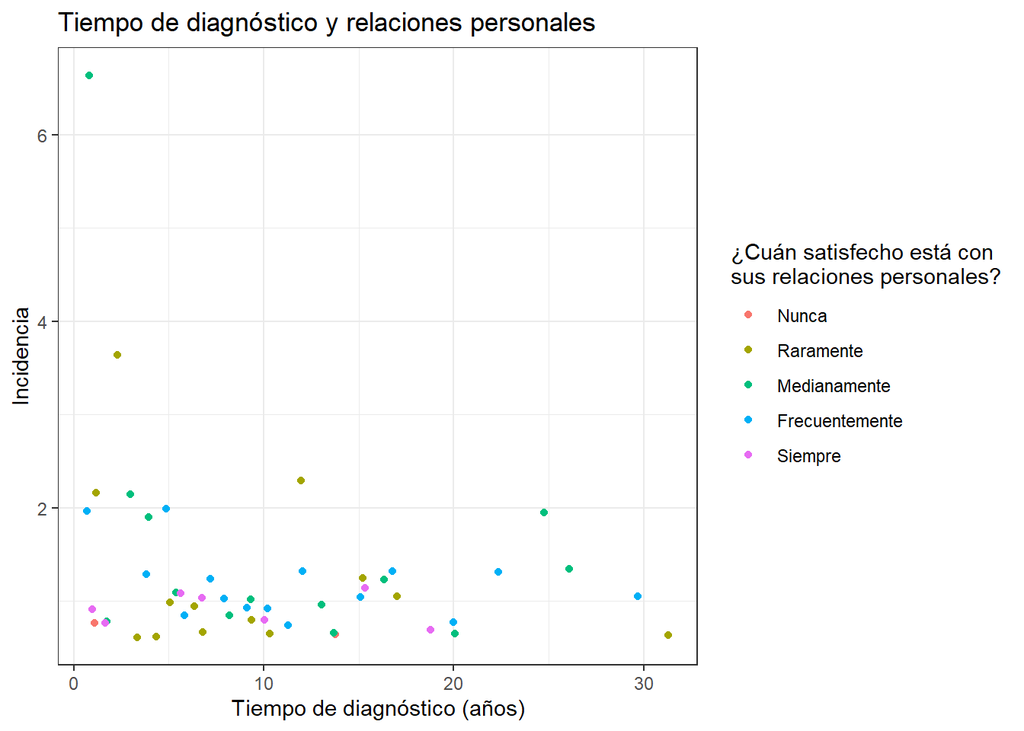

```r
dxTime_relaciones_personales %>%
  ggplot(aes(dx_time, n, colour = relaciones_personales))+
  geom_point(position = "jitter") +
  xlab("Tiempo de diagnóstico (años)") +
  ylab("Incidencia") +
  ggtitle("Tiempo de diagnóstico y relaciones personales") +
  scale_colour_hue(labels = c("Nunca", "Raramente", "Medianamente", "Frecuentemente", "Siempre")) +
  guides(colour=guide_legend(title = "¿Cuán satisfecho está con
sus relaciones personales?")) +
  theme_bw()
```

Esta gráfica indica qué tan satisfecha está la persona con las relaciones personales que ha formado, relacionada con el tiempo de diagnóstico.

### 2.1.21 Vida sexual

¿Cuán satisfecho está con su vida sexual?

```r
dxTime_vida_sexual<-db_lupus %>%
  count(dx_time, vida_sexual, wt = NULL)

dxTime_vida_sexual$vida_sexual<-as.factor(dxTime_vida_sexual$vida_sexual)
```

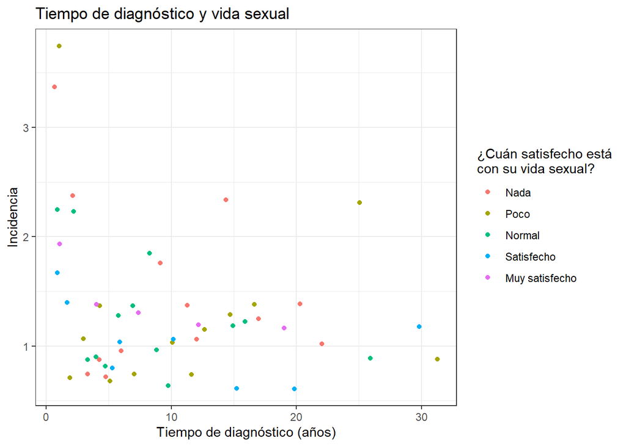

```r
dxTime_vida_sexual %>%
  ggplot(aes(dx_time, n, colour = vida_sexual))+
  geom_point(position = "jitter") +
  xlab("Tiempo de diagnóstico (años)") +
  ylab("Incidencia") +
  ggtitle("Tiempo de diagnóstico y vida sexual") +
  scale_colour_hue(labels = c("Nada", "Poco", "Normal", "Satisfecho", "Muy satisfecho")) +
  guides(colour=guide_legend(title = "¿Cuán satisfecho está
con su vida sexual?")) +
  theme_bw()
```

Esta gráfica indica el nivel de satisfacción de las personas con su vida sexual, dependiendo del tiempo de diagnóstico.

### 2.1.22 Apoyo de los amigos

¿Cuán satisfecho está con el apoyo que obtiene de sus amigos?

```r
dxTime_apoyo_amigos<-db_lupus %>%
  count(dx_time, apoyo_amigos, wt = NULL)

dxTime_apoyo_amigos$apoyo_amigos<-as.factor(dxTime_apoyo_amigos$apoyo_amigos)
```

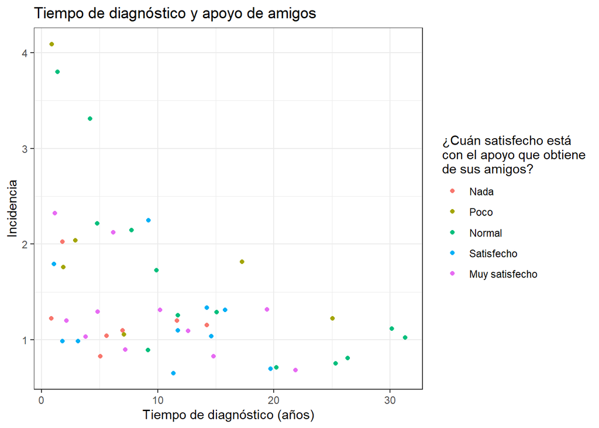

```r
dxTime_apoyo_amigos %>%
  ggplot(aes(dx_time, n, colour = apoyo_amigos))+
  geom_point(position = "jitter") +
  xlab("Tiempo de diagnóstico (años)") +
  ylab("Incidencia") +
  ggtitle("Tiempo de diagnóstico y apoyo de amigos") +
  scale_colour_hue(labels = c("Nada", "Poco", "Normal", "Satisfecho", "Muy satisfecho")) +
  guides(colour=guide_legend(title = "¿Cuán satisfecho está
con el apoyo que obtiene
de sus amigos?")) +
  theme_bw()
```

Esta gráfica indica el nivel de satisfacción de las personas con el apoyo que han recibido de sus amigos, dependiendo del tiempo de diagnóstico.

### 2.1.23 Condiciones de vivienda

¿Cuán satisfecho está de las condiciones del lugar donde vive?

```r
dxTime_condiciones_vivienda<-db_lupus %>%
  count(dx_time, condiciones_vivienda, wt = NULL)

dxTime_condiciones_vivienda$condiciones_vivienda<-as.factor(dxTime_condiciones_vivienda$condiciones_vivienda)
```

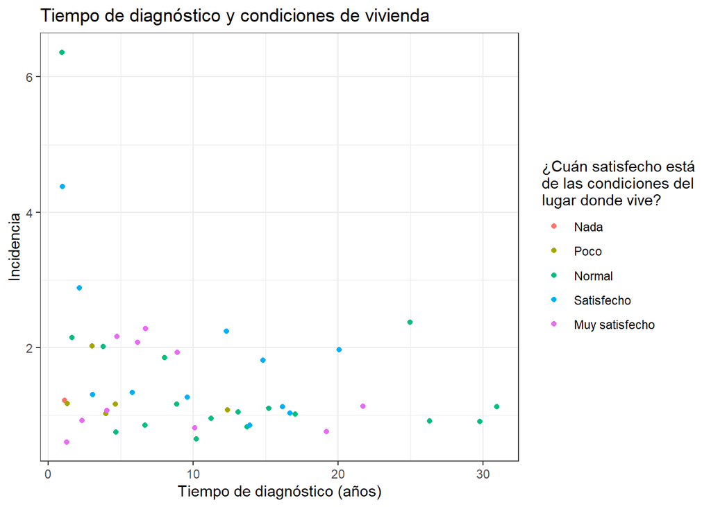

```r
dxTime_condiciones_vivienda %>%
  ggplot(aes(dx_time, n, colour = condiciones_vivienda))+
  geom_point(position = "jitter") +
  xlab("Tiempo de diagnóstico (años)") +
  ylab("Incidencia") +
  ggtitle("Tiempo de diagnóstico y condiciones de vivienda") +
  scale_colour_hue(labels = c("Nada", "Poco", "Normal", "Satisfecho", "Muy satisfecho")) +
  guides(colour=guide_legend(title = "¿Cuán satisfecho está
de las condiciones del
lugar donde vive?")) +
  theme_bw()
```

Esta gráfica indica el nivel de satisfacción de las personas con sus condiciones de vivienda, dependiendo del tiempo de diagnóstico del padecimiento.

### 2.1.24 Acceso a servicios sanitarios

¿Cuán satisfecho está con el acceso que tiene a los servicios sanitarios?

```r
dxTime_acceso_serv_sanitarios<-db_lupus %>%
  count(dx_time, acceso_serv_sanitarios, wt = NULL)

dxTime_acceso_serv_sanitarios$acceso_serv_sanitarios<-as.factor(dxTime_acceso_serv_sanitarios$acceso_serv_sanitarios)
```

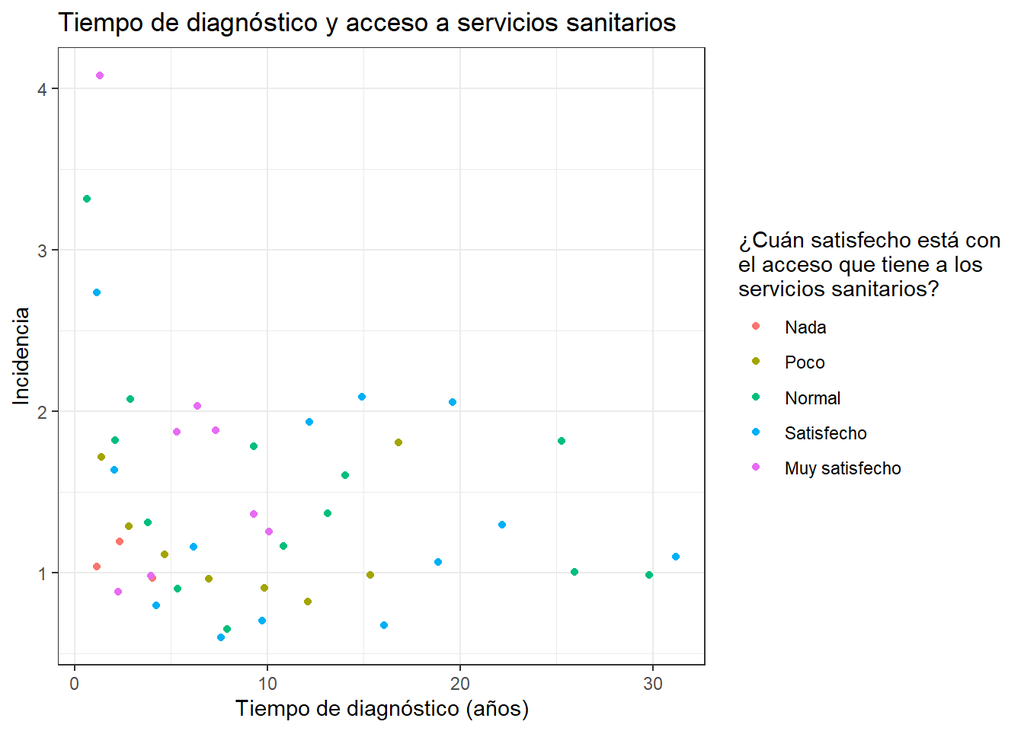

```r
dxTime_acceso_serv_sanitarios %>%
  ggplot(aes(dx_time, n, colour = acceso_serv_sanitarios))+
  geom_point(position = "jitter") +
  xlab("Tiempo de diagnóstico (años)") +
  ylab("Incidencia") +
  ggtitle("Tiempo de diagnóstico y acceso a servicios sanitarios") +
  scale_colour_hue(labels = c("Nada", "Poco", "Normal", "Satisfecho", "Muy satisfecho")) +
  guides(colour=guide_legend(title = "¿Cuán satisfecho está con
el acceso que tiene a los
servicios sanitarios?")) +
  theme_bw()
```

Esta gráfica indica el nivel de satisfacción de las personas con el acceso a servicios sanitarios, dependiendo del tiempo de diagnóstico.

### 2.1.25 Transporte

¿Cuán satisfecho está con su transporte?

```r
dxTime_transporte<-db_lupus %>%
  count(dx_time, transporte, wt = NULL)

dxTime_transporte$transporte<-as.factor(dxTime_transporte$transporte)
```

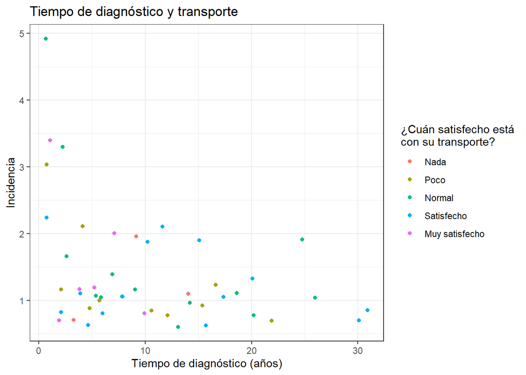

```r
dxTime_transporte %>%
  ggplot(aes(dx_time, n, colour = transporte))+
  geom_point(position = "jitter") +
  xlab("Tiempo de diagnóstico (años)") +
  ylab("Incidencia") +
  ggtitle("Tiempo de diagnóstico y transporte") +
  scale_colour_hue(labels = c("Nada", "Poco", "Normal", "Satisfecho", "Muy satisfecho")) +
  guides(colour=guide_legend(title = "¿Cuán satisfecho está
con su transporte?")) +
  theme_bw()
```

Esta gráfica indica el nivel de satisfacción de las personas con sus medios de transporte, dependiendo del tiempo de diagnóstico.

### 2.1.26 Frencuencia de setimientos negativos

¿Con qué frecuencia tiene sentimientos negativos , tales como tristeza, desesperanza, ansiedad, depresión?

```r
dxTime_frecuencia_sent_neg<-db_lupus %>%
  count(dx_time, frecuencia_sent_neg, wt = NULL)

dxTime_frecuencia_sent_neg$frecuencia_sent_neg<-as.factor(dxTime_frecuencia_sent_neg$frecuencia_sent_neg)
```

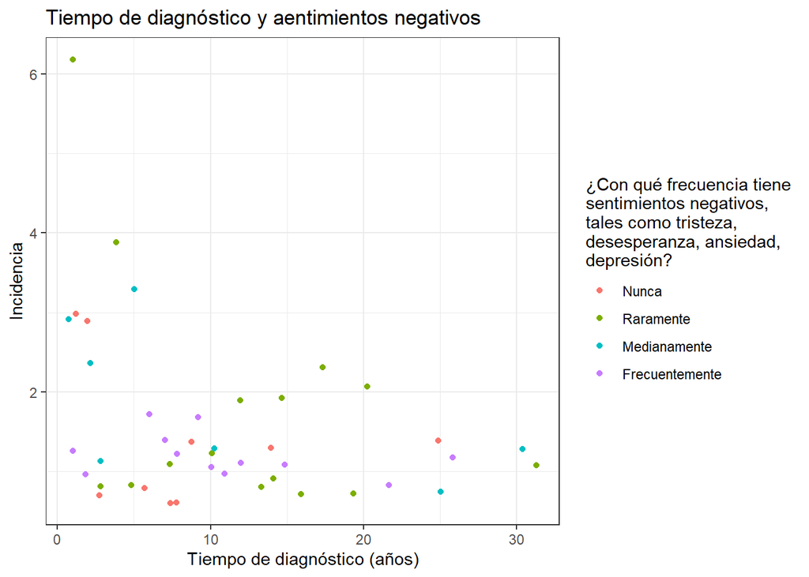

```r
dxTime_frecuencia_sent_neg %>%
  ggplot(aes(dx_time, n, colour = frecuencia_sent_neg))+
  geom_point(position = "jitter") +
  xlab("Tiempo de diagnóstico (años)") +
  ylab("Incidencia") +
  ggtitle("Tiempo de diagnóstico y aentimientos negativos") +
  scale_colour_hue(labels = c("Nunca", "Raramente", "Medianamente", "Frecuentemente", "Siempre")) +
  guides(colour=guide_legend(title = "¿Con qué frecuencia tiene
sentimientos negativos,
tales como tristeza,
desesperanza, ansiedad,
depresión?")) +
  theme_bw()
```

Esta gráfica indica la frecuencia de presentar sentimientos negativos (tristeza, desesperanza, ansiedad, depresión), dependiendo del tiempo de diagnóstico.